# 5: Spatial upscaling

Fabrice Mettler

2025-12-22

# Literature

Answers to the questions after reading the paper by Ludwig et al. (2023)

#### Difference between a random cross-validation and a spatial cross-validation:

In a cross-validation (CV), the dataset is split up in a training and a test (or validation) set. This split can be made randomly (random CV) or based on their spatial information (spatial CV) which, depending on the method, has a critical impact on the model accuracy. The difference gets especially important in the presence of spatially clustered training data. A model trained on random CV holds the ability to make predictions only within the clusters and is usually not suitable for extrapolation. In contrast, for spatial CV, whole clusters are left out and used for validation. This trains the model to be able to better predict data points at new spatial locations. In other words, spatial CV copes better with spatial autocorrelation (which is usually the case in environmental data) as it explicitly separates them.

#### Alternative to geographical distance in Euclidian space:

The geographical distance in Euclidean space works usually well in earth science, as geographically close points usually have similar environmental conditions. However, this is not always the case, especially if we have strong environmental gradients. Additionally, similar environmental conditions occur at places which are geographically far away. One example might be high mountain regions, which are generally more similar to each other than to nearby lowlands. Or one might think of the Mediterranean climate, which occurs around the Mediterranean Sea but also in south-western Australia, California and the Western Cape of South Africa. In this case, it may be more appropriate to use the “environmental closeness” i.e. the environmental feature space. This is a multidimensional space, where datapoints with similar environmental conditions are closer together, independent of geographical location.

# Random cross-validation

```r
# Ensure species is a factor
dfs$Species <- as.factor(dfs$Species)

# Specify target:
target <- "leafN"

# Specify predictors:
predictors <- names(dfs)[4:9]

cat(
  "The target is:", target,
  "\nThe predictors are:", paste0(predictors, sep = ", ")
)
```

```
## The target is: leafN
## The predictors are: elv,  mat,  map,  ndep,  mai,  Species,
```

```r
# set seed
set.seed(101)

# recipe
pp <- recipes::recipe(
  leafN ~ elv + mat + map + ndep + mai + Species,
  data = dfs) |>
  recipes::step_center(recipes::all_numeric_predictors()) |>
  recipes::step_scale(recipes::all_numeric_predictors())

ctrl <- caret::trainControl(
  method = "cv",
  number = 5
)

model_random_cv <- caret::train(
  pp,
  data = dfs |> tidyr::drop_na(),
  method = "ranger",
  trControl = ctrl,
  tuneGrid = expand.grid(
    .mtry = 3,
    .min.node.size = 12,
    .splitrule = "variance"
  ),
  metric = "RMSE",
  seed = 101
)
out_random <- model_random_cv$resample
knitr::kable(model_random_cv$resample)
```

| RMSE | Rsquared | MAE | Resample |
| --- | --- | --- | --- |
| 2.420640 | 0.7725904 | 1.559123 | Fold1 |
| 2.428745 | 0.7735909 | 1.580513 | Fold2 |
| 2.398902 | 0.7865923 | 1.555590 | Fold3 |
| 2.279361 | 0.8023199 | 1.511566 | Fold4 |
| 2.290000 | 0.7964752 | 1.536288 | Fold5 |

```r
cat(
  "Mean RMSE:", mean(model_random_cv$resample$RMSE),
  "Mean R^2:", mean(model_random_cv$resample$Rsquared)
)
```

```
## Mean RMSE: 2.36353 Mean R^2: 0.7863137
```

The RMSE and $R^2$ are similar across the folds.

# Spatial cross-validation

#### distribution

First, lets look at the distribution of our data across the globe:

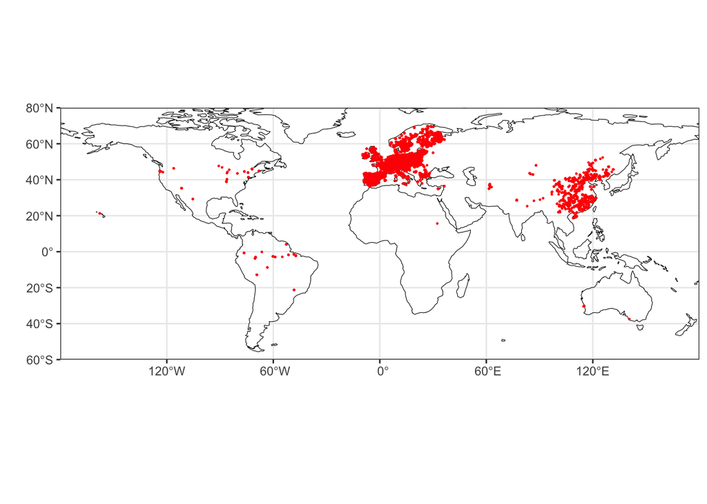

```r
# get coast outline
coast <- rnaturalearth::ne_coastline(scale = 110, returnclass = "sf")

ggplot2::ggplot() +

  # plot coastline
  ggplot2::geom_sf(
    data = coast,
    colour = "black",
    size = 0.2
  ) +

  # set extent in longitude and latitude
  ggplot2::coord_sf(
    ylim = c(-60, 80),
    expand = FALSE
  ) + # to draw map strictly bounded by the specified extent

  # plot points on map
  ggplot2::geom_point(data = dfs, ggplot2::aes(x = lon, y = lat), color = "red", size = 0.2) +
  labs(x = "", y = "") +
  ggplot2::theme_bw() +
  ggplot2::theme(legend.position = "bottom")
```

Most data points are located in Europe and eastern Asia, whereas only a sparse amount of datapoints are located at the rest of the world. This implicates that a model trained with random CV is trained and evaluated mostly on points in Europe and China which probably results an a rather good mean accuracy, as most of the validation points will be located there as well (area of applicability), although the model might not be accurate at predicting in the rest of the world. Since the region in Easter Asia is climatologically very diverse, the environmental CV might perform good, as most of the environmental conditions around the world are represented by some places in Eastern Asia.

#### Identification of geographical clusters

Now, let’s look at the geographical cluster

```r
# cluster the data into 5 classes
set.seed(101)
clusters <- stats::kmeans(
  dfs[, c("lon", "lat")],
  centers = 5
)

dfs$cluster <- factor(clusters$cluster)
```

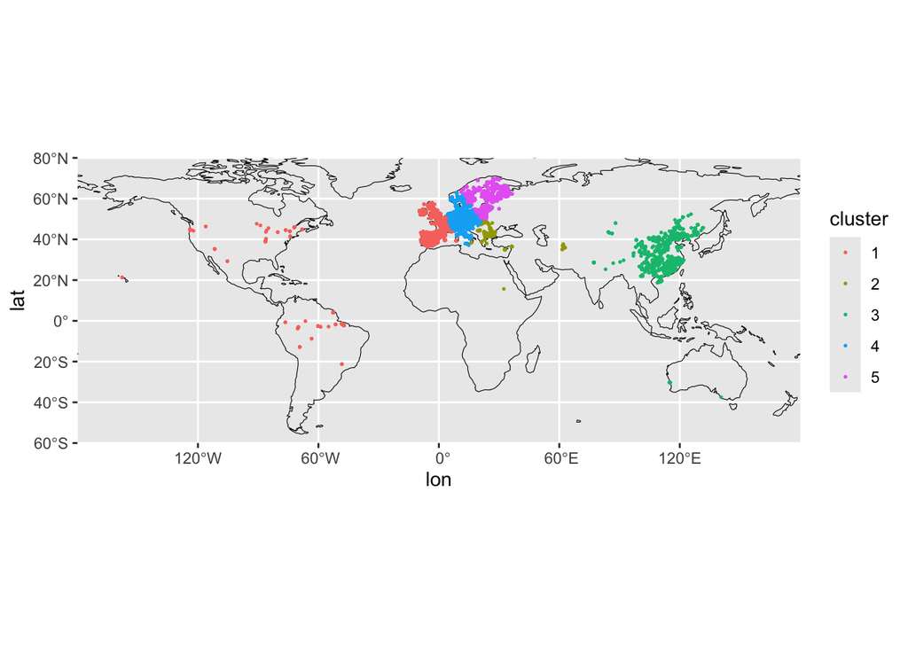

The five clusters are indicated with different colors. We see how points belonging to the same cluster are geographically close together. Interestingly, cluster 1 includes western Europe and the American Continent. The function kmeans() might be limited by the way of how longitude is indicated (reaching from -180 to 180). The function kmeans() probably does not realize that the earth is round and treats points at -179 and 179 as far away.

#### Distribution of leaf N by cluster

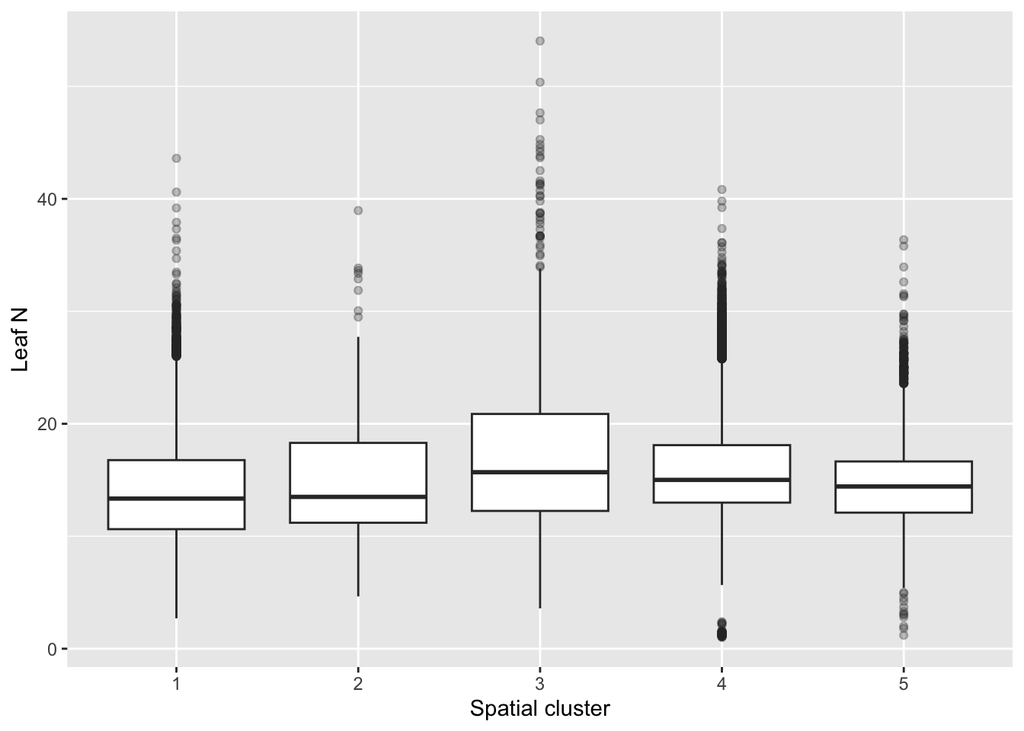

```r
ggplot2::ggplot(dfs, ggplot2::aes(x = cluster, y = leafN)) +
  ggplot2::geom_boxplot(outlier.alpha = 0.3) +
  ggplot2::labs(
    x = "Spatial cluster",
    y = "Leaf N"
  )
```

Leaf nitrogen seems to be more or less evenly distributed over the clusters. Notably, all the cluster have a lot of outliers.

#### Random forest

```r
#df_spat <- dfs
#df_spat$cluster <- sample(1:5, nrow(df_spat), replace = TRUE)

group_folds_train <- purrr::map(
  seq(length(unique(dfs$cluster))),
  ~ {
    dfs |>
      select(cluster) |>
      mutate(idx = 1:n()) |>
      filter(cluster != .) |>
      pull(idx)
  }
)

group_folds_test <- purrr::map(
  seq(length(unique(dfs$cluster))),
  ~ {
    dfs |>
      select(cluster) |>
      mutate(idx = 1:n()) |>
      filter(cluster == .) |>
      pull(idx)
  }
)

# create a function that trains a random forest model on a given set of rows and
# predicts on a disjunct set of rows
train_test_by_fold <- function(idx_train, idx_val){
      data_pred <- dfs |> dplyr::slice(idx_train)
      data_eval <- dfs |> dplyr::slice(idx_val)

  mod <- ranger::ranger(

    x =  data_pred |> select(elv, mat, map, ndep, mai, Species),  # data frame with columns corresponding to predictors
    y =   data_pred |>  select(leafN) |> unlist(),# a vector of the target values (not a data frame!)
    mtry = 3,
    min.node.size = 12,
    splitrule = "variance"
  )

  data_eval$pred <- predict(mod,       # the fitted model object
                  data =  data_eval |>dplyr::select(elv, mat, map, ndep, mai, Species)# a data frame with columns corresponding to predictors
                  )$predictions

  metrics_test <- data_eval |>
  yardstick::metrics(leafN, pred)

  rsq <- metrics_test |>
  filter(.metric == "rsq") |>
  pull(.estimate)  # the R-squared determined on the validation set

  rmse <- metrics_test |>
  filter(.metric == "rmse") |>
  pull(.estimate)# the root mean square error on the validation set

  return(tibble(rsq = rsq, rmse = rmse))
}

# apply function on each custom fold and collect validation results in a nice
# data frame
out_spatial <- purrr::map2_dfr(
  group_folds_train,
  group_folds_test,
  ~train_test_by_fold(.x, .y)
) |>
  mutate(test_fold = 1:5)
tab_spatial <- knitr::kable(out_spatial)
tab_spatial
```

| rsq | rmse | test_fold |
| --- | --- | --- |
| 0.5218969 | 3.869474 | 1 |
| 0.2962698 | 5.248198 | 2 |
| 0.0680490 | 7.008916 | 3 |
| 0.5765312 | 3.371538 | 4 |
| 0.6021110 | 2.353091 | 5 |

```r
cat(
  "Mean RMSE:", mean(out_spatial$rmse),
  "Mean R^2:", mean(out_spatial$rsq)
)
```

```
## Mean RMSE: 4.370243 Mean R^2: 0.4129716
```

Results are discussed later.

# Environmental cross-validation

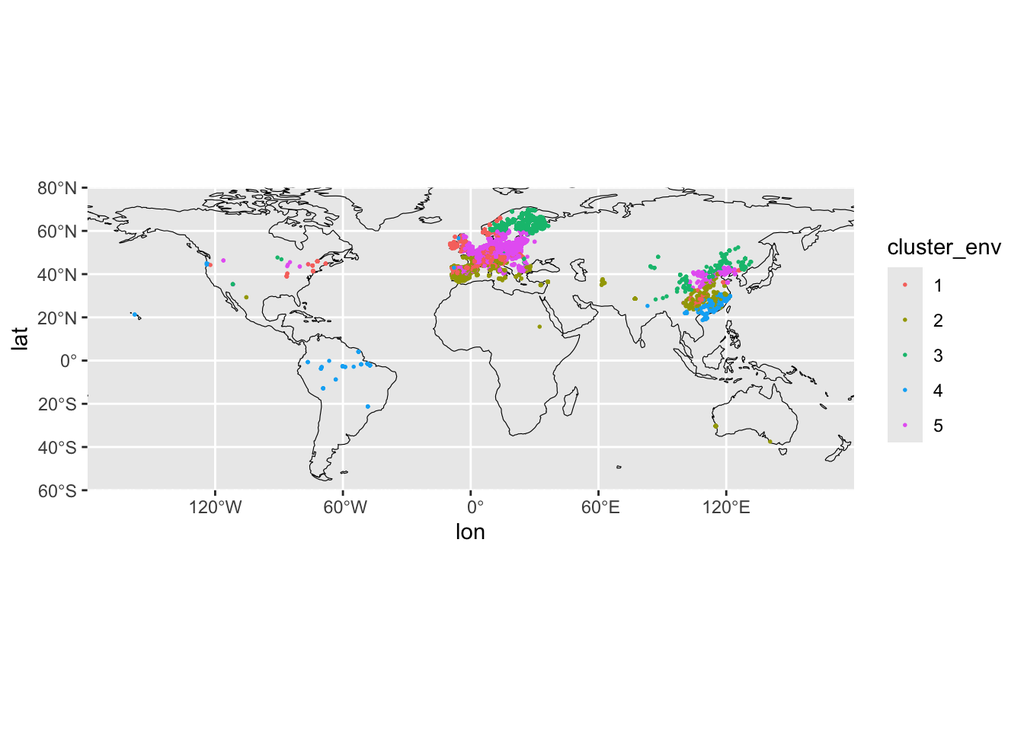

```r
# cluster the data into 5 classes
#set.seed(101)
#clusters_env <- kmeans(
#  dfs[, c("mat", "map")],
#  centers = 5
#)

#dfs$cluster_env <- factor(clusters_env$cluster)

env_vars <- dfs |>
  select(mat, map) |>
  scale()

set.seed(101)
clusters_env <- kmeans(env_vars, centers = 5)
dfs$cluster_env <- factor(clusters_env$cluster)
```

The environmental clusters are presented in the maps above. When combining the information below, we can interpret them. For example, Cluster 4 has high mean annual temperatures and high precipitation. This matches the map as we see cluster 4 (blue), is located in the tropical region in South America and the tropical south of China.

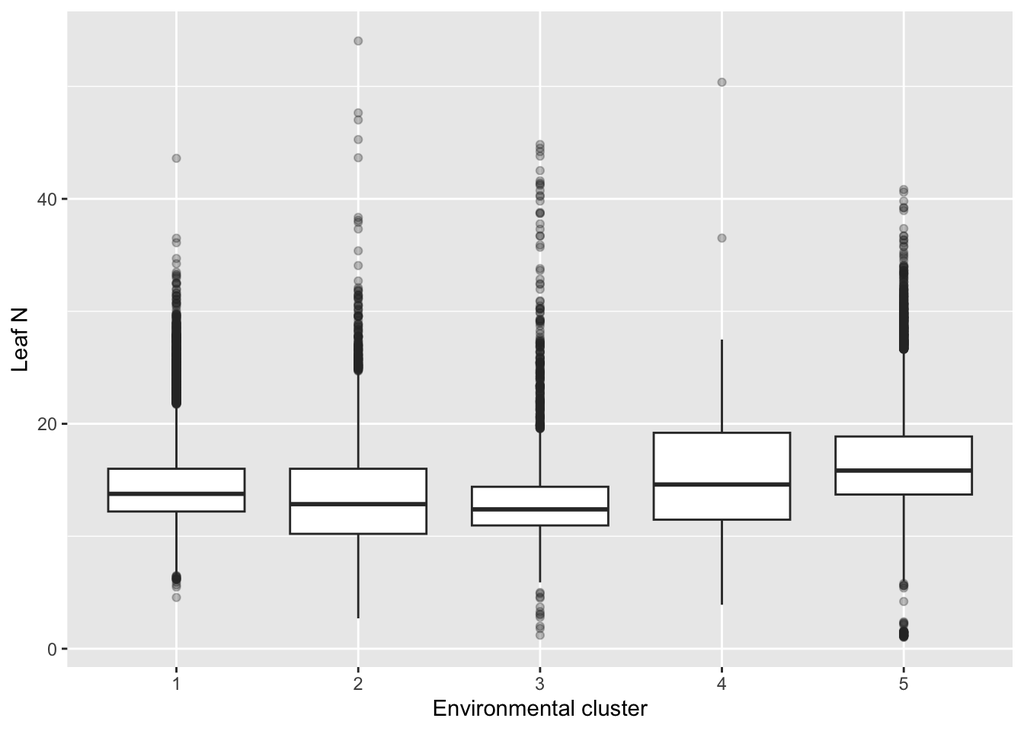

```r
ggplot2::ggplot(dfs, aes(x = cluster_env, y = leafN)) +
  ggplot2::geom_boxplot(outlier.alpha = 0.3) +
  ggplot2::labs(
    x = "Environmental cluster",
    y = "Leaf N"
  )
```

Leaf N again shows a more or less equal distribution among clusters.

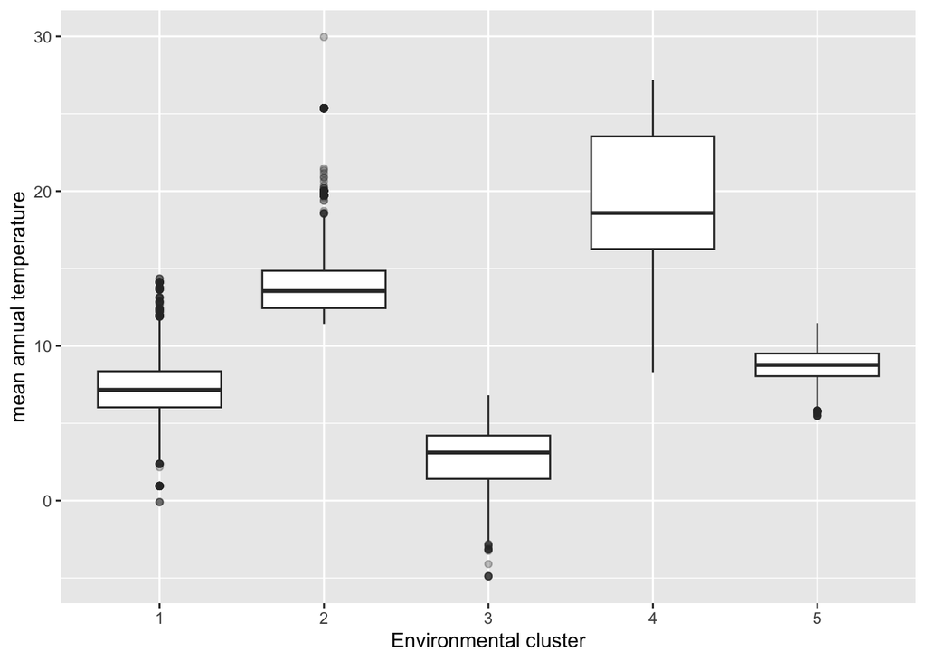

```r
ggplot2::ggplot(dfs, aes(x = cluster_env, y = mat)) +
  ggplot2::geom_boxplot(outlier.alpha = 0.3) +
  ggplot2::labs(
    x = "Environmental cluster",
    y = "mean annual temperature"
  )
```

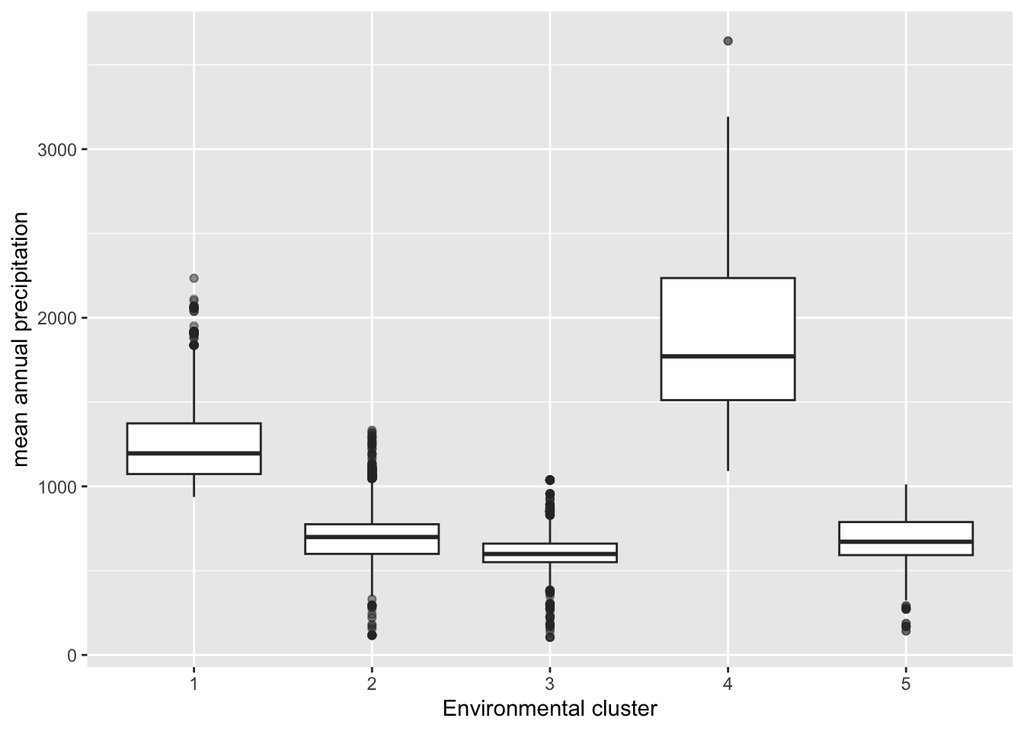

```r
ggplot2::ggplot(dfs, aes(x = cluster_env, y = map)) +
  ggplot2::geom_boxplot(outlier.alpha = 0.3) +
  ggplot2::labs(
    x = "Environmental cluster",
    y = "mean annual precipitation"
  )
```

```r
group_folds_train <- purrr::map(
  seq(length(unique(dfs$cluster_env))),
  ~ {
    dfs |>
      select(cluster_env) |>
      mutate(idx = 1:n()) |>
      filter(cluster_env != .) |>
      pull(idx)
  }
)

group_folds_test <- purrr::map(
  seq(length(unique(dfs$cluster_env))),
  ~ {
    dfs |>
      select(cluster_env) |>
      mutate(idx = 1:n()) |>
      filter(cluster_env == .) |>
      pull(idx)
  }
)


# apply function on each custom fold and collect validation results in a nice
# data frame
out_env <- purrr::map2_dfr(
  group_folds_train,
  group_folds_test,
  ~train_test_by_fold(.x, .y)
) |>
  mutate(test_fold = 1:5)
tab_env <- knitr::kable(out_env)
tab_env
```

| rsq | rmse | test_fold |
| --- | --- | --- |
| 0.6415220 | 2.901002 | 1 |
| 0.5330887 | 3.693623 | 2 |
| 0.4520231 | 3.457473 | 3 |
| 0.2048377 | 4.994477 | 4 |
| 0.5810248 | 3.202430 | 5 |

```r
cat(
  "Mean RMSE:", mean(out_env$rmse),
  "Mean R^2:", mean(out_env$rsq)
)
```

```
## Mean RMSE: 3.649801 Mean R^2: 0.4824993
```

#### Comparison

```r
par(mfrow = c(3, 1))
print(out_random)
```

```
##       RMSE  Rsquared      MAE Resample
## 1 2.420640 0.7725904 1.559123    Fold1
## 2 2.428745 0.7735909 1.580513    Fold2
## 3 2.398902 0.7865923 1.555590    Fold3
## 4 2.279361 0.8023199 1.511566    Fold4
## 5 2.290000 0.7964752 1.536288    Fold5
```

```r
print(out_spatial)
```

```
## # A tibble: 5 × 3
##      rsq  rmse test_fold
##    <dbl> <dbl>     <int>
## 1 0.522   3.87         1
## 2 0.296   5.25         2
## 3 0.0680  7.01         3
## 4 0.577   3.37         4
## 5 0.602   2.35         5
```

```r
print(out_env)
```

```
## # A tibble: 5 × 3
##     rsq  rmse test_fold
##   <dbl> <dbl>     <int>
## 1 0.642  2.90         1
## 2 0.533  3.69         2
## 3 0.452  3.46         3
## 4 0.205  4.99         4
## 5 0.581  3.20         5
```

```r
cat(
  "Random CV\n",
  "Mean RMSE:", mean(model_random_cv$resample$RMSE), "\n",
  "Mean R^2:", mean(model_random_cv$resample$Rsquared), "\n\n",

  "Spatial CV\n",
  "Mean RMSE:", mean(out_spatial$rmse), "\n",
  "Mean R^2:", mean(out_spatial$rsq), "\n\n",

  "Environmental CV\n",
  "Mean RMSE:", mean(out_env$rmse), "\n",
  "Mean R^2:", mean(out_env$rsq), "\n"
)
```

```
## Random CV
##  Mean RMSE: 2.36353
##  Mean R^2: 0.7863137
##
##  Spatial CV
##  Mean RMSE: 4.370243
##  Mean R^2: 0.4129716
##
##  Environmental CV
##  Mean RMSE: 3.649801
##  Mean R^2: 0.4824993
```

When comparing the three CV methods, we see a difference in the resulting RMSE and $R^2$. For random CV, RMSE and $R^2$ are similar across folds. This is expected, as the model is trained in the same geographical and feature space as tested. Bu as mentioned in Ludwig et al. (2023), the area of applicability for this model is limited to the space where training data is located. Differences between folds are more pronounced in the spatial CV and environmental CV. This represents the fact, that there are differences between the geographical space and the feature space. Depending on which places are left out for training, the model struggles more or less to generalize. The spatial CV model has lower mean $R^2$ and higher RMSE compared to the random CV model. This is again expected, as this model was trained for being better at generalization as it was validated on spatially new data. We also see that especially fold nr. 3 seems to be bad at predicting. When looking on the map, we see that cluster 3 is located mostly in china, where we have large differences in environmental conditions in a relatively small geographical area. The environmental CV shows somehow similar results in RMSE and $R^2$ as the spatial CV. This is expected too, as environmental factors are also spatially dependent. The environmental CV outperforms the spatial CV, indicating its potential for such applications.